# MA331-Coursework

Text analytics of the TED talks by Juan Enriquez and Uldus Bakhtiozina

211141-Juliet-Nnajiaku

## **INTRODUCTION.**

This report involves analysis of two (2) **Juan Enriquez and Uldus Bakhtiozina** TED speakers in five(5) talks. Uldus Bakhtiozina gave her talks **wry photos that transforms people into whatever they want to be** in March 2014 and **protraits thet transforms people into whatever they want to be** in April 2017. Uduls is a Russian artist who makes intrigue portraits of people. she uses art to challenge stereotypes and creates diversity, works with models and ordinary people to create imaginations. She holds the opinion that art does not have to involve numbers for it to hold a theory. she does her paintings without the use of any technological filters to achieve authentic paintings.

The other speaker on the other hand,Juan Enriquez spoke on the the topics **Your online life, a permanent tattoo** in February 2013, **The next species of human** February 2013, **The life code that will reshape the future**in February 2003. Juan is an American scientist. In his talks, he spoke about the positive impact of artificial intelligent and technology in the world. He spoke extensively on how these new discoveries in technology not only changes the future in areas of health, where new parts of the body can be made to grow, new species of plants and animals can be created in labs. And how the future will be so different because while the advancement in technology increases the people of that era will advance in intelligence.

## **Methods.**

The following methodology was adopted to analyse this data, which includes;

-Loading of data -Tokenization of words -Tidying and filtering -Sentimental analysis -Calculating the odds ratio.

## **Results**

**Glimpse of the structure of the data**

This steps involves showing the structure of the data, the various speakers and attributes of the data.

```
Rows: 992
Columns: 5
$ talk_id  <dbl> 1, 7, 53, 66, 92, 96, 49, 86, 71, 94, 54, 55, 58, 41, 65, 46,~
$ headline <chr> "Averting the climate crisis", "Simplicity sells", "Greening ~
$ text     <chr> "Thank you so much, Chris. And it's truly a great honor to ha~
$ speaker  <chr> "Al Gore", "David Pogue", "Majora Carter", "Ken Robinson", "H~
$ views    <dbl> 3266733, 1702201, 2000421, 51614087, 12662135, 22368699, 1042~
```

**Filtering and visualization of top words for each speaker**

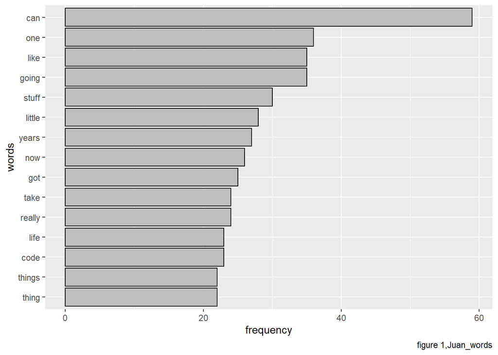

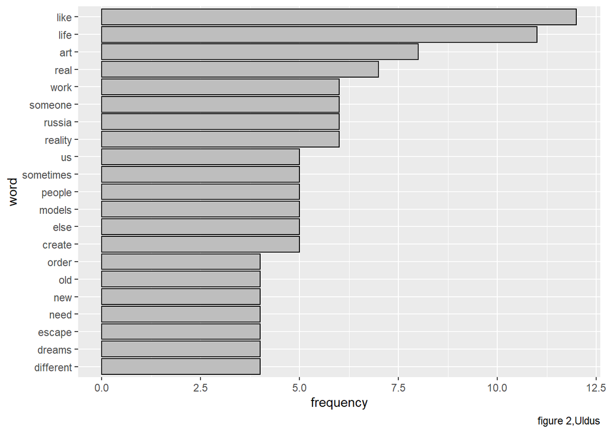

**Comparing speaker words using visualization**

In this step, I went further to compare frequencies of the frequent words between the speakers as seen in figure 3. In plot be in figure 3, the words closer to horizontal axis are words frequently used by Juan in her talks while those words close to the vertical axis words frequently used by Uldus. The words that falls on the line shows the word used frequently by both speakers.

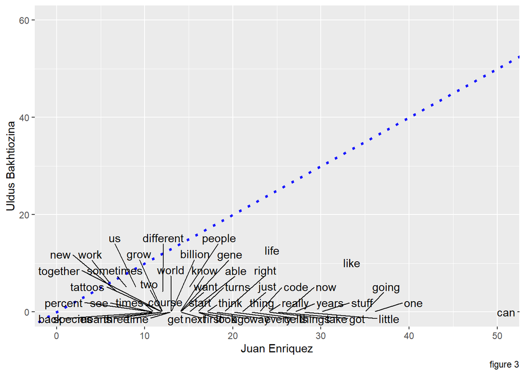

## Sentimental Analysis

**Getting sentiments for each speaker**

```
# A tibble: 10 x 3
   sentiment    `Juan Enriquez` `Uldus Bakhtiozina`
   <chr>                  <int>               <int>
 1 anger                     47                  18
 2 anticipation             175                  47
 3 disgust                   47                  10
 4 fear                     105                  25
 5 joy                      122                  48
 6 negative                 126                  35
 7 positive                 315                 102
 8 sadness                   71                  19
 9 surprise                  70                  25
10 trust                    167                  51
```

**Visualizing sentiments and comparing sentimental words used by each speakers**

Furthermore, to compare sentimental words contained in each speaker’s, the plot shows words like trust,sadness, surprise, positive and negative was more for Jaun and less foe Uldus.

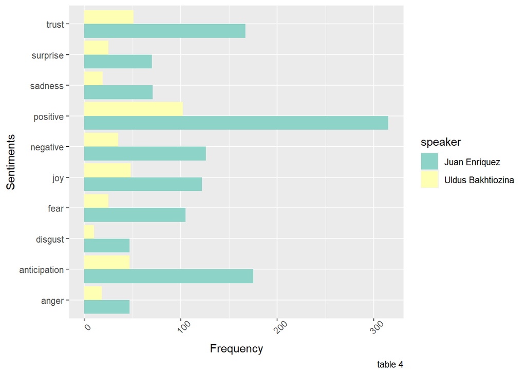

**Percentage of positive words**

The table below show the percentage of postive words by speaker.

```
# A tibble: 2 x 5
# Groups:   speaker [2]
  speaker           sentiment     n total percent
  <chr>             <chr>     <int> <int>   <dbl>
1 Uldus Bakhtiozina positive    102   380   0.268
2 Juan Enriquez     positive    315  1245   0.253
```

**Calculating the Logs ratio for each speaker**

***Visualizing the Log_or against sentiment**

In the plot chart below, sentiments like fear, disgust, anticipation were felt more by Juan while joy,anger surprise was felt more by Uldus.

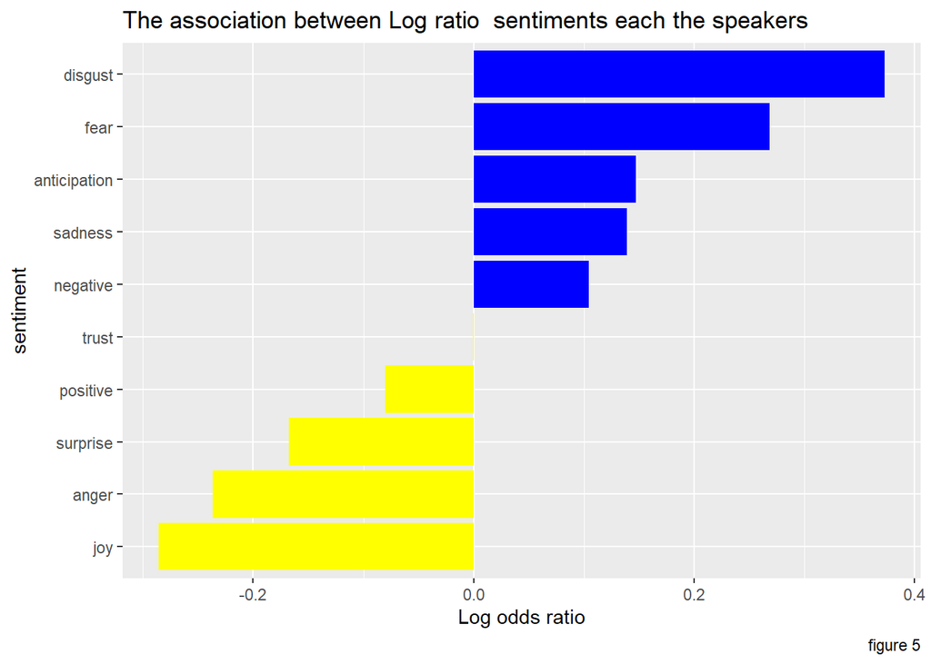

## **Discussion**

Following the analysis of the two speakers, we can observe that Juan Enriquez had more words associated with positive words and negative words when compared to Uldus Bakhtiozina, the plots shows clearly that both speakers even though the spoke about using technology in their concepts used different words.

In future future, the same analysis can be done for equal number of talks of both speakers so as to get the right analysis.